# Genómica Comparativa: largos de los genomas

Prof. Daniela Costa

# Introducción

## ¿Qué es la genómica comparativa?

> **Genómica comparativa:** Colección de todas las actividades de investigación que derivan en la obtención de conocimiento biológico a partir de la comparación sistemática de la información genética (secuencias de ADN, genes, organización genómica, regiones no codificantes) tanto entre diferentes especies como entre individuos de la misma especie.

Su objetivo principal es identificar similitudes y diferencias para:

- Comprender las relaciones evolutivas entre organismos y cómo han divergido a lo largo del tiempo.
- Determinar la función de los genes y otras características genómicas, basándose en su conservación o variación entre especies.
- Identificar las “firmas” de los procesos evolutivos en los genomas.

## ¿Cómo vamos a estudiar los genomas?

En esta unidad vamos a estudiar los genomas de diferentes organismos a tres niveles:

1. Comparación del largo de los genomas de diferentes organismos y su relación con el estilo de vida, y la paradoja del valor C.
2. Composiciones nucleotídicas:
   1. GC entre diferentes genomas
   2. Variación intra-genómica de GC
   3. Sesgos en las composiciones nucleotídicas a lo largo de los genoams
3. Uso de codones sinónimos

# Largo de los genomas

En esta parte partimos de la observacion de que los organismos de una misma especie tienen genomas de aproximadamente el mismo largo:

- *Escherichia coli* str. K-12 substr. MG1655 ([NC_000913.3](https://www.ncbi.nlm.nih.gov/nuccore/NC_000913.3/)): 4.641.652 bases
- *E. coli* O157:H7 str. Sakai (cromosoma, [NC_002695.2](https://www.ncbi.nlm.nih.gov/nuccore/NC_002695.2/)): 5.498.578 bases
- *E. coli* 97-3250 (cromosoma, [CP027599.1](https://www.ncbi.nlm.nih.gov/nuccore/CP027599.1/)): 5.942.969 bases

## Hipótesis

- *A priori* puede parecer que los organismos más *‘complejos’* tienen genomas más largos que los organismos más *‘primitivos’*.
- El estilo de vida de un organismo puede reflejarse en el largo del genoma

## Metodología

Comparamos los largos de los genomas de diferentes organismos y obtenemos informacion sobre su estilo de vida, en el caso de procariotas

## Resultados

Nos basamos en una tabla de que contiene el largo del genoma de diferentes organismos:

```r
largos <- read.table("Largos.tsv", header = T, sep = "\t", fill = T)
largos <- largos %>%
  mutate(Tipo = factor(Tipo,
                       levels = c("Procariota",
                                  "Protista",
                                  "Planta",
                                  "Animal")))
```

| Organismo | Tipo de organismo | Largo del genoma (Mb) | Estilo de vida |
| --- | --- | --- | --- |
| Nanoarchaeum equitans | Procariota | 0.491 | intracelular obligado |
| Methanocaldococcus jannaschii | Procariota | 1.740 | libre |
| Methanosarcina barkeri | Procariota | 4.560 | libre |
| Prochlorococcus marinus | Procariota | 1.702 | libre |
| Escherichia coli | Procariota | 5.142 | libre |
| Bradyrhizobium japonicum | Procariota | 9.224 | libre |
| Mycoplasma pneumoniae | Procariota | 0.817 | intracelular obligado |
| Babesia microti | Protista | 6.630 |  |
| Leishmania major | Protista | 32.855 |  |
| Symbiodinium minutum | Protista | 609.476 | intracelular obligado |
| Ameba | Protista | 670000.000 |  |
| Physcomitrella patens | Planta | 477.948 |  |
| Arabidopsis thaliana | Planta | 107.456 |  |
| Helecho | Planta | 250000.000 |  |
| Drosophila melanogaster | Animal | 148.504 |  |
| Blattella germanica | Animal | 2037.200 |  |
| Homo sapiens | Animal | 2996.420 |  |
| Salamandra | Animal | 120000.000 |  |

A partir de los datos en esta tabla construimos el gráfico de largos vs. organismos con el paquete `ggplot2`.

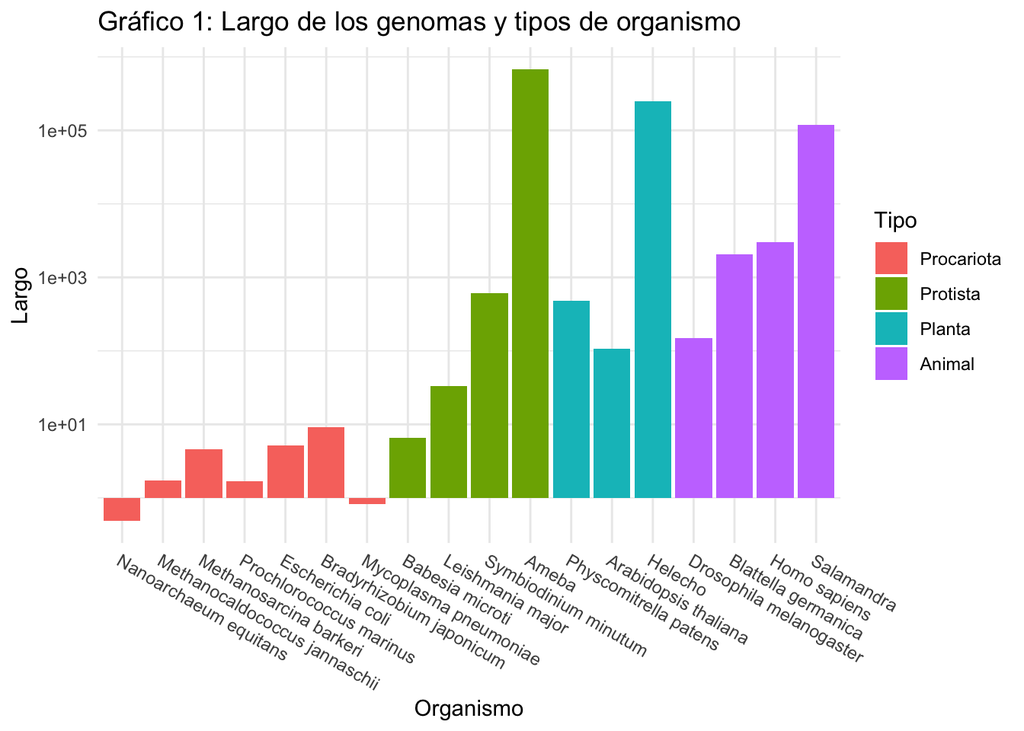

```r
largos %>%
  mutate(Organismo = factor(Organismo, levels = largos$Organismo)) %>%
  ggplot() +
  geom_col(aes(x = Organismo,
               y = Largo,
               fill = Tipo)) +
  scale_y_log10() +
  theme_minimal() +
  theme(axis.text.x = element_text(angle = -30, hjust = 0)) +
  ggtitle(label = "Gráfico 1: Largo de los genomas y tipos de organismo")
```

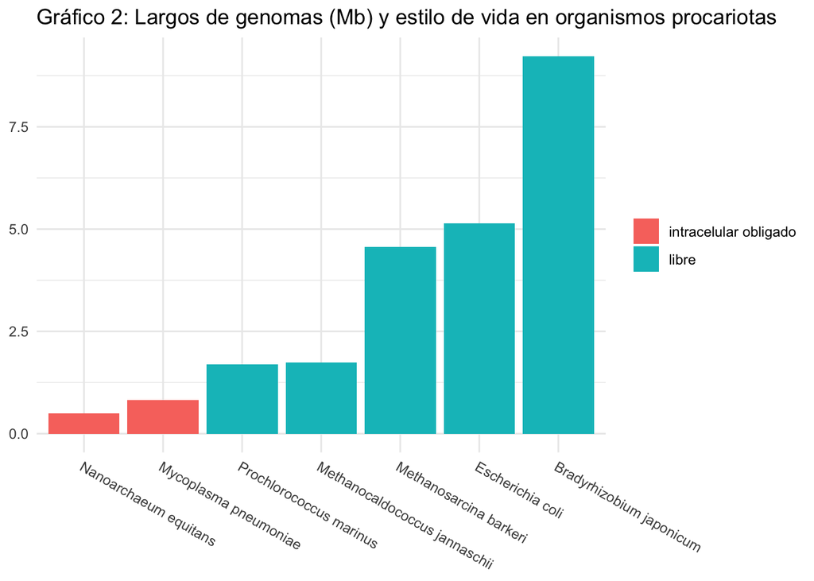

```r
largos_p <- largos %>%
  filter(Tipo == "Procariota") %>%
  arrange(Largo)

largos_p %>%
  mutate(Organismo = factor(Organismo, levels = largos_p$Organismo)) %>%
  ggplot() +
  geom_col(aes(x = Organismo,
               y = Largo,
               fill = Estilo_de_vida)) +
  theme_minimal() +
  theme(axis.text.x = element_text(angle = -30, hjust = 0),
        legend.title = element_blank(),
        axis.title = element_blank()) +
  ggtitle("Gráfico 2: Largos de genomas (Mb) y estilo de vida en organismos procariotas")
```

## Conclusiones

### Largos de los genomas y paradoja del valor C

**Observaciones a partir del Gráfico 1:**

Los genomas procariotas son los más pequeños, lo cual se ajusta a la hipótesis de que los organismos más *primitivos* tienen menores genomas. Sin embargo, al ver los genomas de plantas, animales y protistas, se observan genomas particularmente grandes en cada grupo:

> **Valor C:** Cantidad en picogramos de ADN haploide en una célula.

> **Paradoja del valor C:** La cantidad de ADN en una célula no se correlaciona con la complejidad biológica aparente del organismo.

### Largos de los genomas y estilo de vida en organismos procariotas

**Observaciones a partir del Gráfico 2:**

El largo de los genomas se relaciona con el estilo de vida en organismos procariotas. Los organismos de vida libre tienden a tener genomas más grandes que los intracelulares obligados.

> En procariotas, el estilo de vida impulsa la pérdida de genes (lo que lleva a genomas pequeños en parásitos) o el mantenimiento de un repertorio genético diverso (lo que lleva a genomas grandes en organismos de vida libre), lo que demuestra una clara relación entre la ecología y la evolución del tamaño del genoma bacteriano.